# Recall trend analysis

Rongrong Dai

7/24/2020

Auto manufacturers that determine a vehicle has a safety defect will conduct a recall campaign. During a recall all vehicle owners will be notified there is a problem and are asked to contact their auto dealership to schedule vehicle service to correct or resolve the safety concern.

When recalls affect a large number of vehicles, day-to-day business at the dealerships can be disrupted causing a drop in new vehicle sales, part sales or tire replacements. Understanding the frequency and size of recalls is important for any company working in the automotive industry.

The National Highway Traffic Safety Administration (NHTSA) is a federal agency that requires auto manufacturers to notify the public when a significant safety concern is identified. The information is available in data tables stored on the website for NHTSA’s Office of Defects Investigation.

In this project, I imported data from the NHTSA web site and analyzed the recall trend for different manufacturers. Moreover,according to the recall frequency and size, I grouped the manufacturers using hierarchical clustering.

## 1. Load the package

```r
library(readr)
library(dplyr)
library(lubridate)
library(ggplot2)
library(tidyr)
library(broom)
library(purrr)
```

## 2. Load the data

Load data from URL to import the up-to-date data, the default setting of import function doesn’t work well, customized parameters. Add column names and set column types. The meaning of the column names can be found in https://www-odi.nhtsa.dot.gov/downloads/folders/Recalls/RCL.txt

```r
#set up temporary file to download the zip recall file
temp <- tempfile()
download.file("https://www-odi.nhtsa.dot.gov/downloads/folders/Recalls/FLAT_RCL.zip",temp)

# read into r and customize parameters based on metadata
recall_df <- read_delim(unz(temp, "FLAT_RCL.txt"), '\t', quote = "",
                        col_names =
                          c("RECORD_ID", "CAMPNO", "MAKETXT",
                            "MODELTXT", "YEARTXT","MFGCAMPNO",
                            "COMPNAME", "MFGNAME","BGMAN", "ENDMAN",
                            "RCLTYPECD", "POTAFF", "ODATE",
                            "INFLUENCED_BY", "MFGTXT",
                            "RCDATE", "DATEA", "RPNO", "FMVSS",
                            "DESC_DEFECT","CONEQUENCE_DEFECT",
                            "CORRECTIVE_ACTION","NOTES", "RCL_CMPT_ID",
                            "MFR_COMP_NAME","MFR_COMP_DESC", "MFR_COMP_PTNO"),
                        col_types = cols(
                          .default = col_character(),
                          RECORD_ID = col_double(),
                          BGMAN = col_date("%Y%m%d"),
                          ENDMAN = col_date("%Y%m%d"),
                          ODATE = col_date("%Y%m%d"),
                          RCDATE = col_date("%Y%m%d"),
                          DATEA = col_date("%Y%m%d"),
                          POTAFF = col_double()
                          )
                        )


unlink(temp)
```

## 3. Generate dataset focus on specific manufacturers

```r
recall_df <- recall_df %>%
  mutate(target_mfr =
            case_when(
    grepl("BMW", MFGTXT, ignore.case = T) == TRUE ~ "BMW",
    grepl("NISSAN", MFGTXT, ignore.case = T) == TRUE ~ "NISSAN",
    grepl("INFINITI", MFGTXT, ignore.case = T) == TRUE ~ "INFINITI",
    grepl("VOLVO", MFGTXT, ignore.case = T) == TRUE ~ "VOLVO",
    grepl("TOYOTA", MFGTXT, ignore.case = T) == TRUE ~ "TOYOTA",
    grepl("MINI", MFGTXT, ignore.case = T) == TRUE ~ "MINI",
    grepl("AUDI", MFGTXT, ignore.case = T) == TRUE ~ "AUDI",
    grepl("KIA", MFGTXT, ignore.case = T) == TRUE ~ "KIA",
    grepl("HONDA", MFGTXT, ignore.case = T) == TRUE ~ "HONDA",
    grepl("MOPAR", MFGTXT, ignore.case = T) == TRUE ~ "MOPAR",
    grepl("MERCEDES", MFGTXT, ignore.case = T) == TRUE ~ "MERCEDES",
    grepl("VOLKSWAGEN", MFGTXT, ignore.case = T) == TRUE ~ "VOLKSWAGEN",
    grepl("MAZDA", MFGTXT, ignore.case = T) == TRUE ~ "MAZDA",
    grepl("JAGUAR", MFGTXT, ignore.case = T) == TRUE ~ "JAGUAR",
    grepl("SUBARU", MFGTXT, ignore.case = T) == TRUE ~ "SUBARU",
    grepl("LEXUS", MFGTXT, ignore.case = T) == TRUE ~ "LEXUS",
    grepl("HYUNDAI", MFGTXT, ignore.case = T) == TRUE ~ "HYUNDAI",
    grepl("LAND ROVER", MFGTXT, ignore.case = T) == TRUE ~ "LAND ROVER",
    grepl("ACURA", MFGTXT, ignore.case = T) == TRUE ~ "ACURA",
    grepl("PORSCHE", MFGTXT, ignore.case = T) == TRUE ~ "PORSCHE",

  )) %>%
  filter(!is.na(target_mfr))

# Check the number of records for each manufacturer, display it in descending
# order
recall_df %>% group_by(target_mfr)%>% summarise(n = n()) %>% arrange(desc(n))
```

```
## # A tibble: 16 x 2
##    target_mfr     n
##    <chr>      <int>
##  1 HONDA       4067
##  2 BMW         3711
##  3 TOYOTA      3352
##  4 VOLVO       3097
##  5 MERCEDES    2270
##  6 VOLKSWAGEN  2208
##  7 NISSAN      1754
##  8 SUBARU      1184
##  9 MAZDA        752
## 10 HYUNDAI      724
## 11 PORSCHE      655
## 12 JAGUAR       599
## 13 KIA          408
## 14 LAND ROVER   361
## 15 AUDI           9
## 16 MINI           1
```

## 4. Check the data quality and clean the data

```r
#summary(recall_df)

check_BGMAN <- recall_df[!is.na(recall_df$BGMAN) &
                           (year(recall_df$BGMAN) < 1968),
                         c("BGMAN", "ENDMAN", "DATEA")]
tail(check_BGMAN)
```

```
## # A tibble: 6 x 3
##   BGMAN      ENDMAN     DATEA
##   <date>     <date>     <date>
## 1 1900-01-01 1900-01-01 2017-05-04
## 2 1900-01-01 1900-01-01 2017-05-04
## 3 1900-01-01 1900-01-01 2017-05-04
## 4 1900-01-01 1900-01-01 2020-03-19
## 5 1900-01-01 1900-01-01 2020-03-19
## 6 0209-02-11 2010-08-17 2019-07-01
```

```r
# Some records with BEGIN DATE OF MANUFACTURING earlier than 1901 are
# problematic. Since that is small portion(9 records), we got rid of them
recall_BGMAN_df <-
  recall_df[!is.na(recall_df$BGMAN) & (year(recall_df$BGMAN) > 1900),]

#hist(as.numeric(recall_BGMAN_df$DATEA - recall_BGMAN_df$BGMAN))
summary(as.numeric(recall_BGMAN_df$DATEA - recall_BGMAN_df$BGMAN))
```

```
##    Min. 1st Qu.  Median    Mean 3rd Qu.    Max.
##   -2600     615    1716    2145    3347   11029
```

```r
# A small portion of data(14 records) create the report before manufacturing,
# get rid of them, since the data for 1979 is not just for 1979 but for
# the total counts before 1979. To analyze the trend, I only include data after
# 1980.

recall_BGMAN_df <-
recall_BGMAN_df[
  as.numeric(recall_BGMAN_df$DATEA - recall_BGMAN_df$BGMAN) > 0,] %>%
  mutate(YEAR_DATEA = year(DATEA)) %>%
  filter(YEAR_DATEA > 1980)
```

Although a small portion of data have problem about the begin date of manufacturing, their other records seem to be fine. We will still use those data when the analysis doesn’t involve the begin date of manufacturing

## 5. Data analysis

### 5.1. The number of recalls and affected vehicles with year considering

### all manufacurers

```r
# The number of recalls by year
recall_byYear_df <- recall_df %>%
                    mutate(YEAR_DATEA = year(DATEA)) %>%
                    select(YEAR_DATEA, CAMPNO) %>%
                    distinct(CAMPNO, .keep_all = T) %>%
                    group_by(YEAR_DATEA) %>%
                    summarise(rcTotal_byYear = n()) %>%
                    arrange(YEAR_DATEA)

head(recall_byYear_df)
```

```
## # A tibble: 6 x 2
##   YEAR_DATEA rcTotal_byYear
##        <dbl>          <int>
## 1       1979            455
## 2       1980             26
## 3       1981             21
## 4       1982             21
## 5       1983             19
## 6       1984             32
```

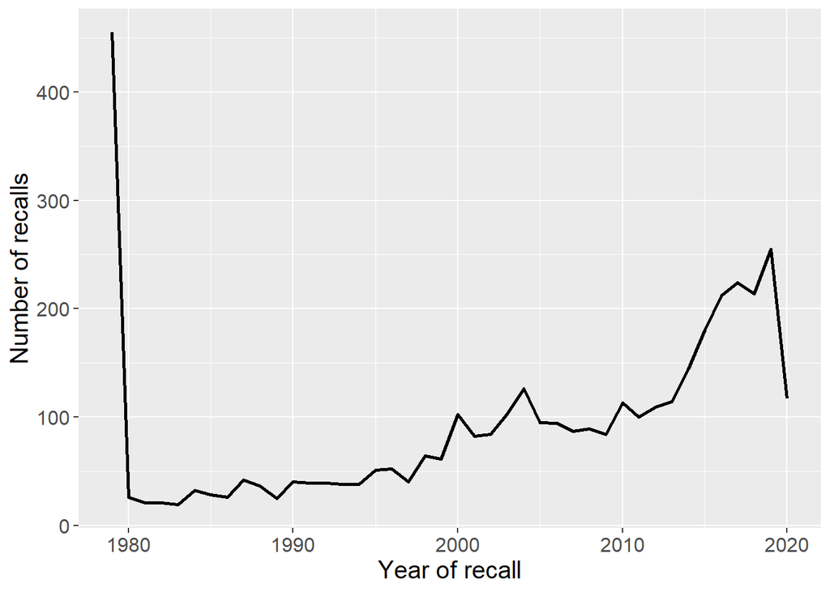

```r
recall_byYear_plot <- ggplot(aes(x = YEAR_DATEA, y = rcTotal_byYear),
                       data = recall_byYear_df) +
  geom_line(size = 1, show.legend = F) +
  xlab("Year of recall") + ylab("Number of recalls") +
  theme(text = element_text(size=15))

recall_byYear_plot
```

```r
# The number of affected vehicles by year
affCount_byYear_df <- recall_df %>%
                      mutate(YEAR_DATEA = year(DATEA)) %>%
                      filter(!is.na(POTAFF)) %>% group_by(YEAR_DATEA) %>%
                      summarise(affTotal_byYear = sum(POTAFF))

head(affCount_byYear_df)
```

```
## # A tibble: 6 x 2
##   YEAR_DATEA affTotal_byYear
##        <dbl>           <dbl>
## 1       1979       162314408
## 2       1980         2780628
## 3       1981        16133729
## 4       1982         1208613
## 5       1983        39097130
## 6       1984         1870914
```

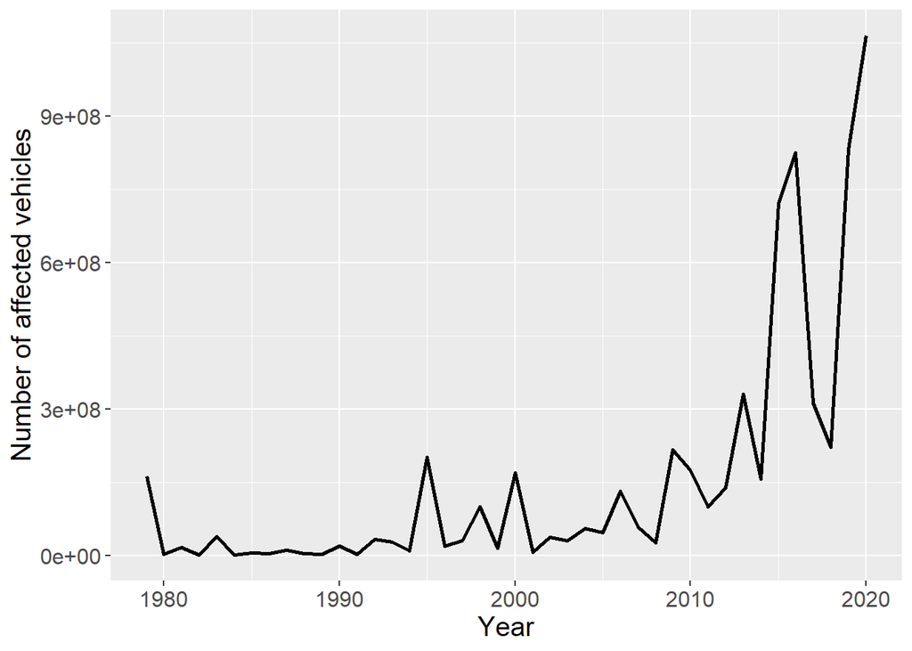

```r
affCount_byYear_plot <- ggplot(aes(x = YEAR_DATEA, y = affTotal_byYear),
                       data = affCount_byYear_df) +
  geom_line(size = 1, show.legend = F) +
  xlab("Year") + ylab("Number of affected vehicles") +
  theme(text = element_text(size=15))

affCount_byYear_plot
```

The significant drop in 1980 is may be because the data for 1979 is not just for 1979 but for the total counts before 1979. To analyze the trend, I only include data after 1980.

```r
# Filter data to only include those after 1980
recall_after1980 <- recall_df %>% mutate(YEAR_DATEA = year(DATEA)) %>%
                         filter(YEAR_DATEA > 1980)
```

### 5.2 Examine each manufacturer’s contribution to the number of recalls

### and affected vehicles

Plot top 3 manufacturers that have most recalls and affected vehicles in recent 5 years

```r
# Top 3 manufacturers that have most recalls in Recent 5 years
Current_year <- max(year(recall_df$DATEA))
recall_Recent5y <- recall_df %>% mutate(YEAR_DATEA = year(DATEA)) %>%
  filter(YEAR_DATEA > (Current_year - 5))

recall_mfr_Recent5y <- recall_Recent5y %>%
                       select(YEAR_DATEA, CAMPNO, target_mfr) %>%
                       distinct(CAMPNO, .keep_all = T) %>%
                       group_by(YEAR_DATEA, target_mfr) %>%
                       summarise(recallCount = dplyr::n())%>%
                       group_by(YEAR_DATEA) %>%
                       mutate(percent = recallCount/sum(recallCount)) %>%
                       top_n(3, percent) %>%
                       arrange(YEAR_DATEA)
other_mfr_Recent5y <- data.frame("YEAR_DATEA" = (Current_year-4):Current_year,
                                 "target_mfr" = "Other",
                                 "percent" =
                                   recall_mfr_Recent5y %>%
                                   group_by(YEAR_DATEA) %>%
                                   summarise(percent =
                                               1- sum(percent))%>%
                                   select(percent))


recall_mfr_Recent5y <- rbind(recall_mfr_Recent5y,other_mfr_Recent5y)

recall_mfr_Recent5y
```

```
## # A tibble: 20 x 4
## # Groups:   YEAR_DATEA [5]
##    YEAR_DATEA target_mfr recallCount percent
##         <dbl> <chr>            <int>   <dbl>
##  1       2016 MERCEDES            24   0.113
##  2       2016 TOYOTA              25   0.118
##  3       2016 VOLKSWAGEN          24   0.113
##  4       2017 BMW                 31   0.138
##  5       2017 MERCEDES            39   0.174
##  6       2017 VOLKSWAGEN          28   0.125
##  7       2018 BMW                 26   0.121
##  8       2018 MERCEDES            32   0.150
##  9       2018 VOLKSWAGEN          34   0.159
## 10       2019 BMW                 42   0.165
## 11       2019 MERCEDES            40   0.157
## 12       2019 VOLKSWAGEN          28   0.110
## 13       2020 BMW                 18   0.154
## 14       2020 MERCEDES            21   0.179
## 15       2020 VOLKSWAGEN          13   0.111
## 16       2016 Other               NA   0.656
## 17       2017 Other               NA   0.562
## 18       2018 Other               NA   0.570
## 19       2019 Other               NA   0.569
## 20       2020 Other               NA   0.556
```

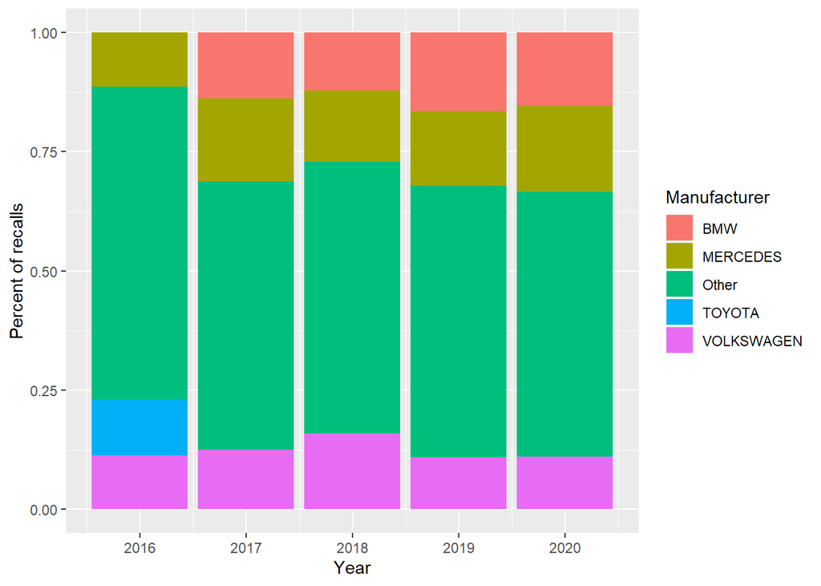

```r
ggplot(data=recall_mfr_Recent5y,
       aes(x=YEAR_DATEA, y=percent, fill=target_mfr)) +
         geom_bar(stat="identity")  +
           ylab("Percent of recalls") +xlab("Year") +
              scale_fill_discrete(name = "Manufacturer")
```

```r
# Top 3 manufacturers that have most affected vehicles in Recent 5 years
aff_mfr_Recent5y <- recall_Recent5y %>%
                       group_by(YEAR_DATEA, target_mfr) %>%
                       summarise(affCount = sum(POTAFF))%>%
                       group_by(YEAR_DATEA) %>%
                       mutate(percent = affCount/sum(affCount)) %>%
                       top_n(3, percent) %>%
                       arrange(YEAR_DATEA)



other_Aff_Recent5y <- data.frame("YEAR_DATEA" = (Current_year-4):Current_year,
                                 "target_mfr" = "Other",
                                 "percent" =
                                   aff_mfr_Recent5y %>%
                                   group_by(YEAR_DATEA) %>%
                                   summarise(percent =
                                               1- sum(percent))%>%
                                   select(percent))


aff_mfr_Recent5y <- rbind(aff_mfr_Recent5y,other_Aff_Recent5y)

aff_mfr_Recent5y
```

```
## # A tibble: 20 x 4
## # Groups:   YEAR_DATEA [5]
##    YEAR_DATEA target_mfr  affCount percent
##         <dbl> <chr>          <dbl>   <dbl>
##  1       2016 HONDA      336048713  0.407
##  2       2016 NISSAN     181422836  0.220
##  3       2016 TOYOTA     110277383  0.134
##  4       2017 BMW         88905818  0.285
##  5       2017 HONDA       65304600  0.209
##  6       2017 MERCEDES    57911858  0.185
##  7       2018 HONDA       90263821  0.407
##  8       2018 TOYOTA      43039889  0.194
##  9       2018 VOLKSWAGEN  33849740  0.152
## 10       2019 HONDA      223948460  0.269
## 11       2019 MERCEDES    90346242  0.109
## 12       2019 TOYOTA     262509030  0.316
## 13       2020 HONDA      673288668  0.632
## 14       2020 TOYOTA     214540491  0.202
## 15       2020 VOLVO       50257174  0.0472
## 16       2016 Other             NA  0.239
## 17       2017 Other             NA  0.321
## 18       2018 Other             NA  0.247
## 19       2019 Other             NA  0.307
## 20       2020 Other             NA  0.119
```

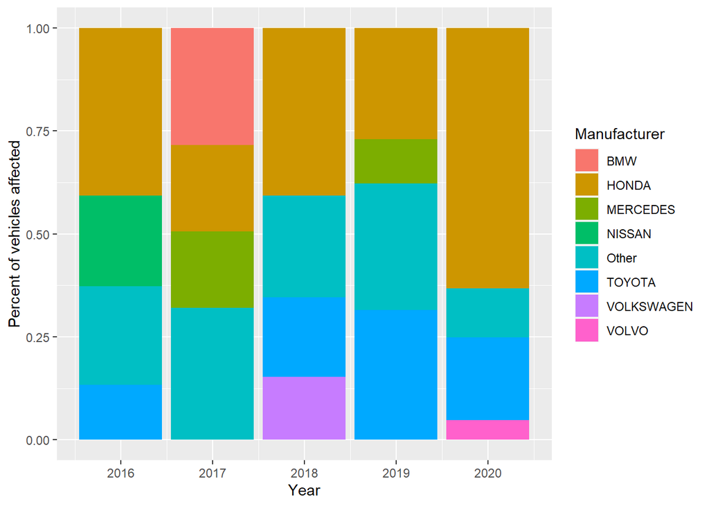

```r
label_aff <- aff_mfr_Recent5y %>% ungroup() %>% select(target_mfr) %>%                          distinct(target_mfr)
ggplot(data=aff_mfr_Recent5y,
       aes(x=YEAR_DATEA, y=percent, fill=target_mfr)) +
          geom_bar(stat="identity")  +
           ylab("Percent of vehicles affected") +xlab("Year") +
            scale_fill_discrete(name = "Manufacturer")
```

Calculate the total counts of recall and affected vehicles for each manufacturer

```r
recall_mfr_after1980 <- recall_after1980 %>%
                       select(CAMPNO, target_mfr) %>%
                       distinct(CAMPNO, target_mfr, .keep_all = T) %>%
                       group_by(target_mfr) %>%
                       summarise(recallCount = n())%>%
                       arrange(recallCount)
recall_mfr_after1980
```

```
## # A tibble: 15 x 2
##    target_mfr recallCount
##    <chr>            <int>
##  1 AUDI                 5
##  2 LAND ROVER         101
##  3 JAGUAR             112
##  4 KIA                113
##  5 PORSCHE            114
##  6 SUBARU             141
##  7 MAZDA              196
##  8 HYUNDAI            210
##  9 MERCEDES           289
## 10 NISSAN             342
## 11 VOLVO              347
## 12 VOLKSWAGEN         358
## 13 HONDA              386
## 14 TOYOTA             388
## 15 BMW                423
```

```r
aff_mfr_after1980 <- recall_after1980 %>%
                       filter(!is.na(recall_after1980$POTAFF)) %>%
                       group_by(target_mfr) %>%
                       summarise(affCount = sum(POTAFF))%>%
                       arrange(affCount)
aff_mfr_after1980
```

```
## # A tibble: 15 x 2
##    target_mfr   affCount
##    <chr>           <dbl>
##  1 AUDI            15703
##  2 LAND ROVER    7975912
##  3 JAGUAR       11981478
##  4 PORSCHE      13603954
##  5 KIA         103644262
##  6 VOLVO       111370762
##  7 SUBARU      207786041
##  8 MERCEDES    230898480
##  9 HYUNDAI     256013990
## 10 MAZDA       282277060
## 11 VOLKSWAGEN  337911923
## 12 BMW         472023450
## 13 NISSAN      568874565
## 14 TOYOTA     1440148650
## 15 HONDA      2160191721
```

### 5.3. Trends for each manufacturer focus on the number of campaigns and

### the number of vehicles affected by specific recall campaigns

Different manufacturers have different trends in the number of campaigns and vehicles affected. Take JAGUAR and TOYOTA as examples, plot their trends.

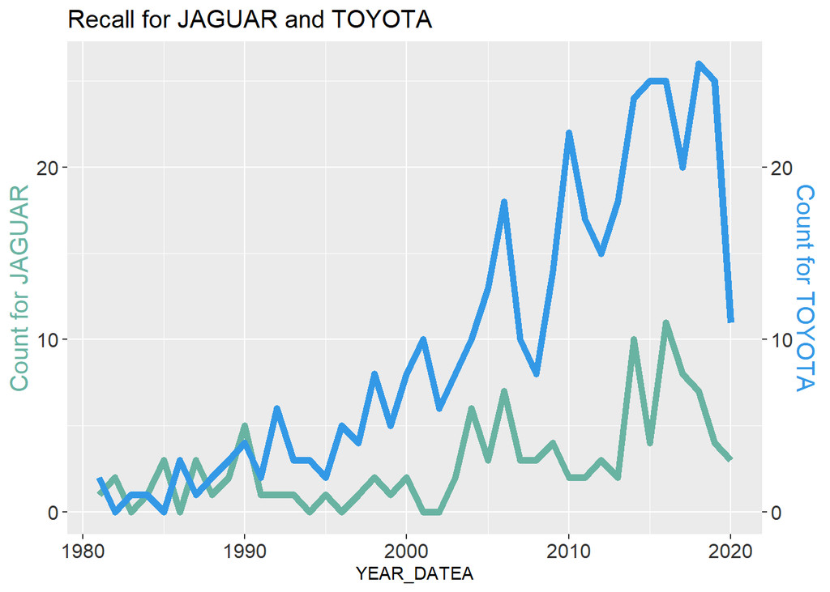

```r
# Create recall data for each manufacturer as a function of year
Create_mfrRecall <- function(x){
                    recall_after1980 %>%
                       filter(target_mfr == x) %>%
                       select(YEAR_DATEA, CAMPNO) %>%
                       distinct(CAMPNO, .keep_all = T) %>%
                       group_by(YEAR_DATEA) %>%
                       summarise(count_byYear = n()) %>%
                       arrange(desc(YEAR_DATEA))

}

# Create affected vehicle data for each manufacturer as a function of year
Create_mfrAff <- function(x){
                    recall_after1980 %>%
                       filter(!is.na(recall_after1980$POTAFF)) %>%
                       filter(target_mfr == x) %>%
                       select(YEAR_DATEA, POTAFF) %>%
                       group_by(YEAR_DATEA) %>%
                       summarise(count_byYear = log(sum(POTAFF))) %>%
                       arrange(desc(YEAR_DATEA))

}


JAGUAR_TOYOTA_df <- merge(
  Create_mfrRecall("JAGUAR") %>% rename(count_JAGUAR=count_byYear),
  Create_mfrRecall("TOYOTA") %>% rename(count_TOYOTA=count_byYear),
                          all = TRUE)

JAGUAR_TOYOTA_df[is.na(JAGUAR_TOYOTA_df)] = 0

plot_TwoMfr <- function(x, y) {
  countColor <- "#69b3a2"
  percentageColor <- rgb(0.2, 0.6, 0.9, 1)
  coeff = 1

  ggplot(data = x, aes(x=YEAR_DATEA)) +

        geom_line( aes(y=count_JAGUAR), size=2, color=countColor) +
        geom_line( aes(y=count_TOYOTA), size=2, color=percentageColor) +

        scale_y_continuous(

        # Features of the first axis
        name = "Count for JAGUAR",

        # Add a second axis and specify its features
        sec.axis = sec_axis(~./coeff, name="Count for TOYOTA")
        ) +
        ggtitle(y) +
        theme(
          axis.title.y = element_text(color = countColor, size=15),
          axis.title.y.right = element_text(color = percentageColor, size=15),
          axis.text.x = element_text(color = "grey20", size = 12),
          axis.text.y = element_text(color = "grey20", size = 12),
          plot.title = element_text(color = "black", size = 15)
        )

}

plot_TwoMfr(JAGUAR_TOYOTA_df, "Recall for JAGUAR and TOYOTA")
```

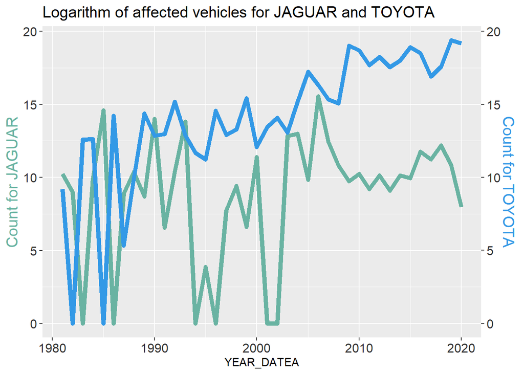

```r
JAGUAR_TOYOTA_Aff_df <- merge(
  Create_mfrAff("JAGUAR") %>% rename(count_JAGUAR=count_byYear),
  Create_mfrAff("TOYOTA") %>% rename(count_TOYOTA=count_byYear),
                          all = TRUE)

JAGUAR_TOYOTA_Aff_df[is.na(JAGUAR_TOYOTA_Aff_df)] = 0
plot_TwoMfr(JAGUAR_TOYOTA_Aff_df,
            "Logarithm of affected vehicles for JAGUAR and TOYOTA")
```

Slope of the linear fit of counts by year can quantify the trend for different manufacturers. The number of vehicles is changed to the logarithm of the count before the fit.

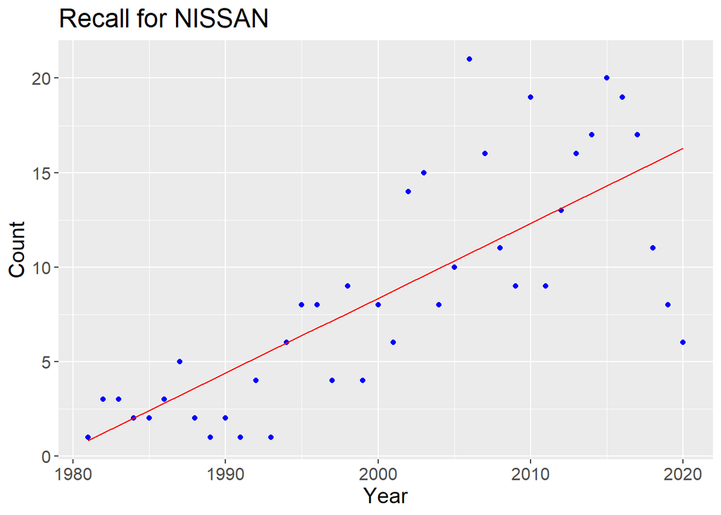

```r
target_mfr_list <- c( "BMW","NISSAN","INFINITI","VOLVO","TOYOTA","MINI",
                        "AUDI","KIA","HONDA","MOPAR","MERCEDES","VOLKSWAGEN",
                        "MAZDA","JAGUAR","SUBARU","LEXUS","HYUNDAI",
                        "LAND ROVER","ACURA","PORSCHE")


# Plot the trend, plotType_indicator indicates whether this plot is for recall or
# affected vehicle
Plot_mfr_byYear <- function(data, x, mfr, plotType_indicator){
  if(nrow(data) > 1) {
    lm_fit <- lm(data$count_byYear ~ x)

    predicted_df <- data.frame(cbind(x,
                                   count_pred = predict(lm_fit, data)))

    title <- paste(plotType_indicator, " for ", mfr, sep = "")
    ylab <- "Count"
    if (plotType_indicator != "Recall"){
      ylab <- "log(count)"
    }
   countColor <- "#69b3a2"


    print(ggplot(data = data, aes(x = YEAR_DATEA, y = count_byYear)) +
            geom_point(color='blue') +
            geom_line(color='red',data = predicted_df, aes(x=x, y=count_pred))+
            xlab("Year") + ylab(ylab) +
            ggtitle(title) +
            theme(text = element_text(size=15)))

     }

}

Plot_mfr_byYear(Create_mfrRecall("NISSAN"),
                    Create_mfrRecall("NISSAN")$YEAR_DATEA,
                    "NISSAN",
                    "Recall")
```

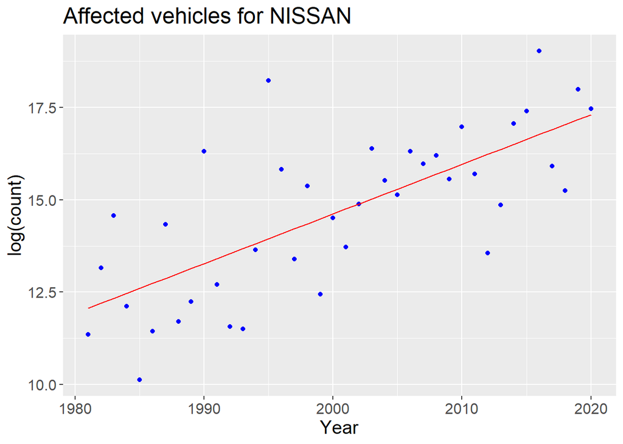

```r
Plot_mfr_byYear(Create_mfrAff("NISSAN"),
                    Create_mfrRecall("NISSAN")$YEAR_DATEA,
                    "NISSAN",
                    "Affected vehicles")
```

Different manufacturers have different slopes of increasing in the number of campaigns and vehicles affected

```r
# test dplyr function
test_lm <- function(){

}


# Define a funtion to get the coefficients of the linear fit
slope_mfr_byYear <- function(data, x, mfr, plotType_indicator){
# If manufacturers have more than 1 records do the linear fit
    if(nrow(data) > 1) {
    lm_fit <- lm(data$count_byYear ~ x)
    coefficients = paste (mfr, "\t",
                          plotType_indicator,"\t",
                          unlist(lm_fit$coefficients)[1], "\t",
                          unlist(lm_fit$coefficients)[2], "\t", sep = "")
    lapply(coefficients, write, "rcAff_fit_coefficients.txt", append=TRUE)
  }

}

unlink("rcAff_fit_coefficients.txt")
for (i in target_mfr_list){
  # Check whether specific manufacturer has recalls
  if(sum(recall_after1980$target_mfr == i) > 0){
    # If it has recalls, then fit the trend for recall and affected vehicles
    # and get the coeffieients
    slope_mfr_byYear(Create_mfrRecall(i),
                    Create_mfrRecall(i)$YEAR_DATEA,
                    i,
                    "Recall")
    slope_mfr_byYear(Create_mfrAff(i),
                    Create_mfrRecall(i)$YEAR_DATEA,
                    i,
                    "Affected vehicles")
  }

}

fit_coefficient <-
  (cbind(read_delim("rcAff_fit_coefficients.txt", '\t', quote = "",
                              col_names = c("target_mfr", "trend_type",
                                             "intercept", "slope")
                              ) %>% filter(trend_type == "Recall"),
  read_delim("rcAff_fit_coefficients.txt", '\t', quote = "",
            col_names = c("target_mfr", "trend_type",
                           "intercept", "slope")
            ) %>% filter(trend_type == "Affected vehicles")))[, c(1,3,4,7,8)] %>%
  rename(Recall_intercept = intercept,
         Recall_slope = slope,
         Aff_intercept = intercept.1,
         Aff_slope = slope.1)


fit_coefficient$Recall_intercept = as.numeric(fit_coefficient$Recall_intercept)
fit_coefficient$Recall_slope = as.numeric(fit_coefficient$Recall_slope)
fit_coefficient$Aff_intercept = as.numeric(fit_coefficient$Aff_intercept)
fit_coefficient$Aff_slope = as.numeric(fit_coefficient$Aff_slope)
fit_coefficient
```

```
##    target_mfr Recall_intercept  Recall_slope Aff_intercept  Aff_slope
## 1         BMW       -1356.3903  6.832743e-01    -330.87657 0.17235151
## 2      NISSAN        -784.5188  3.964353e-01    -253.74665 0.13418159
## 3       VOLVO        -316.5470  1.625704e-01    -140.24569 0.07658982
## 4      TOYOTA       -1271.9175  6.406172e-01    -450.64716 0.23256536
## 5        AUDI           1.0000 -2.334006e-17     -49.12954 0.02777333
## 6         KIA        -501.8533  2.521368e-01    -510.38378 0.26063168
## 7       HONDA       -1011.6184  5.105066e-01    -368.90403 0.19189908
## 8    MERCEDES       -1219.7812  6.132978e-01    -348.11021 0.18008694
## 9  VOLKSWAGEN        -776.9875  3.928705e-01     -94.96032 0.05470652
## 10      MAZDA        -347.8805  1.763869e-01    -145.09520 0.07919169
## 11     JAGUAR        -243.3233  1.232036e-01     -21.38745 0.01586299
## 12     SUBARU        -355.0790  1.793213e-01    -243.90042 0.12865010
## 13    HYUNDAI        -711.0867  3.580416e-01    -253.09976 0.13310301
## 14 LAND ROVER        -241.4406  1.221451e-01    -204.52130 0.10734336
## 15    PORSCHE        -257.1993  1.301823e-01    -131.35178 0.07072152
```

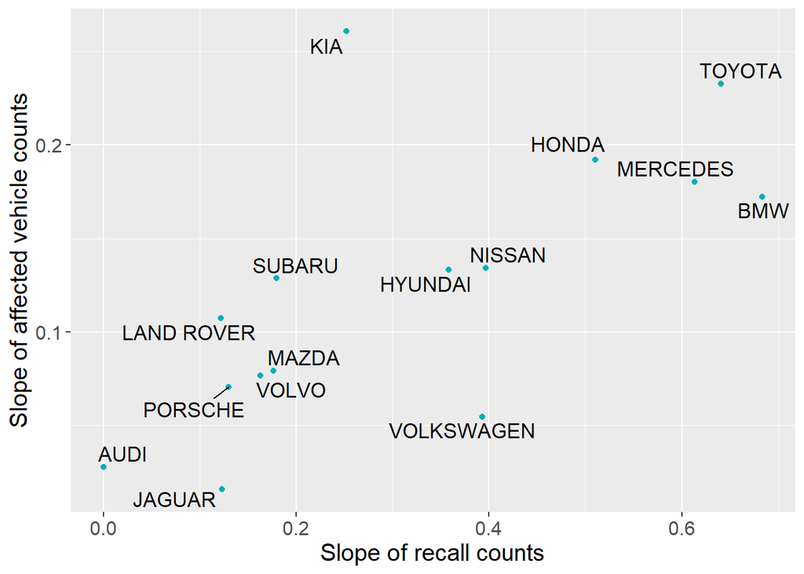

```r
require("ggrepel")
ggplot(data = fit_coefficient, aes(x = Recall_slope, y = Aff_slope)) +
  geom_point(color = "#00AFBB") +
  geom_text_repel(aes(label = fit_coefficient$target_mfr,
                    size = 3.5))  +
  xlab("Slope of recall counts") + ylab("Slope of affected vehicle counts")+
  theme(text = element_text(size=15)) +
  theme(legend.position = "none")
```

### 5.4. Check time intervals for each manufacturer to have a recall

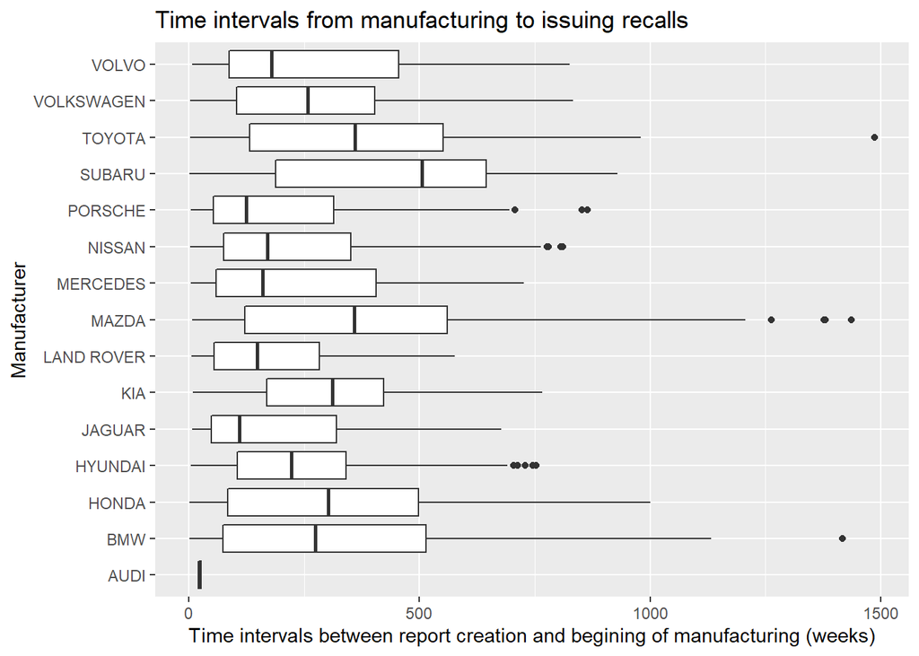

```r
recall_BGMAN_df$dateDiff_DATEA_BGMAN <- as.numeric(
  difftime(recall_BGMAN_df$DATEA,recall_BGMAN_df$BGMAN,units = "weeks"))
mfr_dateDiff <- recall_BGMAN_df %>% select(target_mfr, dateDiff_DATEA_BGMAN)

p <- ggplot(mfr_dateDiff, aes(x=dateDiff_DATEA_BGMAN, y=target_mfr)) +
  geom_boxplot()
p + labs(title="Time intervals from manufacturing to issuing recalls ",x="Time intervals between report creation and begining of manufacturing (weeks)", y = "Manufacturer")
```

```r
mfr_dateDiff <- recall_BGMAN_df %>% group_by(target_mfr) %>%
                summarise(
                median_dateDiff = median(dateDiff_DATEA_BGMAN),
                sd_dateDiff = sd(dateDiff_DATEA_BGMAN)) %>%
                arrange(median_dateDiff)

mfr_dateDiff
```

```
## # A tibble: 15 x 3
##    target_mfr median_dateDiff sd_dateDiff
##    <chr>                <dbl>       <dbl>
##  1 AUDI                  23.6        6.46
##  2 JAGUAR               110.       188.
##  3 PORSCHE              124        206.
##  4 LAND ROVER           149.       156.
##  5 MERCEDES             160.       201.
##  6 NISSAN               171.       209.
##  7 VOLVO                179.       229.
##  8 HYUNDAI              223.       165.
##  9 VOLKSWAGEN           258.       183.
## 10 BMW                  275.       247.
## 11 HONDA                303.       251.
## 12 KIA                  312.       178.
## 13 MAZDA                358.       334.
## 14 TOYOTA               361.       326.
## 15 SUBARU               506.       299.
```